# R Notebook

packages we need to do some logits

```r
library(car)
```

Let´s load the data. We use the data from field again - that is, the eel data.

Let´s have a look at our variables

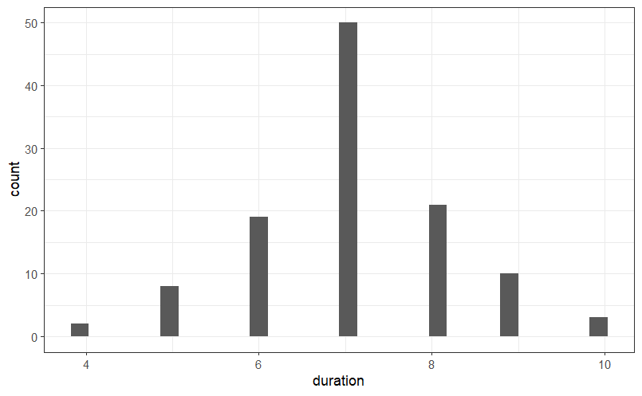

```r
data %>%
  ggplot(aes(x = duration))+
  geom_histogram()+
  theme_bw()
```

Looks very nice, first we will do a univariate logistic regression and then add a the dumy variable of intervention. We formulate our model the same way as in the normal regression but use the glm function instead of the lm function. Since we are using a glm, we also need to specify what link function we will use, we will use logit since, well…this is a chapter on logit.

```r
summary.glm(m1)
```

```
Call:
glm(formula = cured ~ duration, family = binomial(link = "logit"),
    data = data)

Deviance Residuals:
    Min       1Q   Median       3Q      Max
-1.4747  -1.3049   0.9548   1.0551   1.1603

Coefficients:
            Estimate Std. Error z value Pr(>|z|)
(Intercept)  -0.5951     1.1680  -0.510    0.610
duration      0.1271     0.1634   0.778    0.436

(Dispersion parameter for binomial family taken to be 1)

    Null deviance: 154.08  on 112  degrees of freedom
Residual deviance: 153.47  on 111  degrees of freedom
AIC: 157.47

Number of Fisher Scoring iterations: 4
```

Interesting, the duration does not seem to increase the probability of being cured. Let´s check if the intervention alone increases the probability of being cured.

```r
summary.glm(m2)
```

```
Call:
glm(formula = cured ~ intervention, family = binomial(link = "logit"),
    data = data)

Deviance Residuals:
    Min       1Q   Median       3Q      Max
-1.5940  -1.0579   0.8118   0.8118   1.3018

Coefficients:
             Estimate Std. Error z value Pr(>|z|)
(Intercept)   -0.2877     0.2700  -1.065  0.28671
intervention   1.2287     0.3998   3.074  0.00212 **
---
Signif. codes:  0 ‘***’ 0.001 ‘**’ 0.01 ‘*’ 0.05 ‘.’ 0.1 ‘ ’ 1

(Dispersion parameter for binomial family taken to be 1)

    Null deviance: 154.08  on 112  degrees of freedom
Residual deviance: 144.16  on 111  degrees of freedom
AIC: 148.16

Number of Fisher Scoring iterations: 4
```

It certenly does, let´s fit a multivariate logistic regression using both variables.

```r
summary.glm(m3)
```

```
Call:
glm(formula = cured ~ duration + intervention, family = binomial(link = "logit"),
    data = data)

Deviance Residuals:
    Min       1Q   Median       3Q      Max
-1.6025  -1.0572   0.8107   0.8161   1.3095

Coefficients:
              Estimate Std. Error z value Pr(>|z|)
(Intercept)  -0.234660   1.220563  -0.192  0.84754
duration     -0.007835   0.175913  -0.045  0.96447
intervention  1.233532   0.414565   2.975  0.00293 **
---
Signif. codes:  0 ‘***’ 0.001 ‘**’ 0.01 ‘*’ 0.05 ‘.’ 0.1 ‘ ’ 1

(Dispersion parameter for binomial family taken to be 1)

    Null deviance: 154.08  on 112  degrees of freedom
Residual deviance: 144.16  on 110  degrees of freedom
AIC: 150.16

Number of Fisher Scoring iterations: 4
```

No, duration does not matter even when we adjust for the intervention. We might have an interaction though, so let´s fit a model with interactions

```r
summary.glm(m4)
```

```
Call:
glm(formula = cured ~ duration * intervention, family = binomial(link = "logit"),
    data = data)

Deviance Residuals:
    Min       1Q   Median       3Q      Max
-1.6510  -1.0611   0.8045   0.8412   1.3285

Coefficients:
                      Estimate Std. Error z value Pr(>|z|)
(Intercept)           -0.52033    1.68409  -0.309    0.757
duration               0.03436    0.24540   0.140    0.889
intervention           1.85049    2.53509   0.730    0.465
duration:intervention -0.08694    0.35200  -0.247    0.805

(Dispersion parameter for binomial family taken to be 1)

    Null deviance: 154.08  on 112  degrees of freedom
Residual deviance: 144.09  on 109  degrees of freedom
AIC: 152.09

Number of Fisher Scoring iterations: 4
```

Huh, if we include an interaction term no variables are significant predictors. Let´s stick with the model without the interaction and check for any influential observations

| res |
| --- |
| 1.103415 |
| 1.103415 |
| 1.098457 |
| 1.098457 |
| 1.098457 |
| 1.093537 |
| 1.093537 |
| 1.093537 |
| 1.093537 |
| 1.093537 |

I don´t think we need to exlude any variables, so let´s check our assumptions and then make you model interpretable.

```r
#Checking independence
durbinWatsonTest(m3)
```

```
 lag Autocorrelation D-W Statistic p-value
   1      -0.1881671      2.363961   0.052
 Alternative hypothesis: rho != 0
```

This is not very good. Thd statistic is approaching significance, it is close to two however. Lets check the VIF and tolerance.

```r
1/vif(m3)
```

```
    duration intervention
   0.9298601    0.9298601
```

Very solid, no issues here. Lets finally go through the linearity assumption. We can use the box-tidwell test for this. Or just check visually. Lets start with the latter.

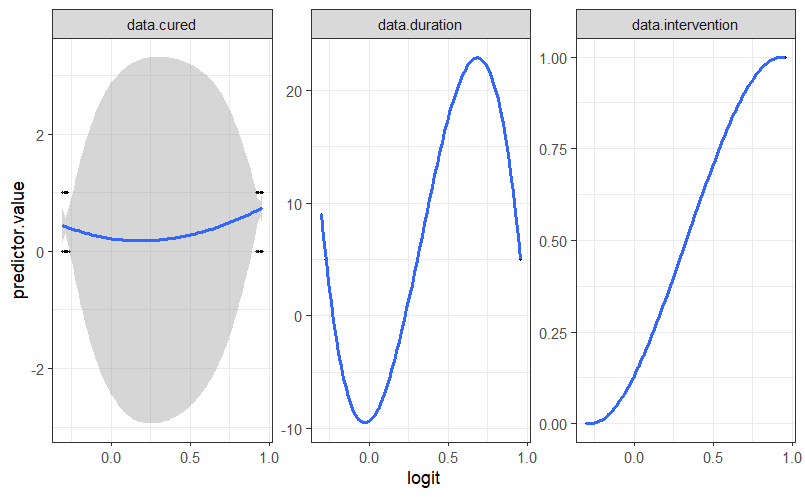

```r
ggplot(df, aes(logit, predictor.value))+
  geom_point(size = 0.5, alpha = 0.5) +
  geom_smooth(method = "loess") +
  theme_bw() +
  facet_wrap(~predictors, scales = "free_y")
```

No good, duration is not linear to the logit, we should drop it. We won´t be doing much harm to our model anyways. Thus, let´s continue with model 2(m2). Now we want to interpret the model, I like to use absolute probabilites. This is not appropriate in this scenario since we dont have a continous variable.

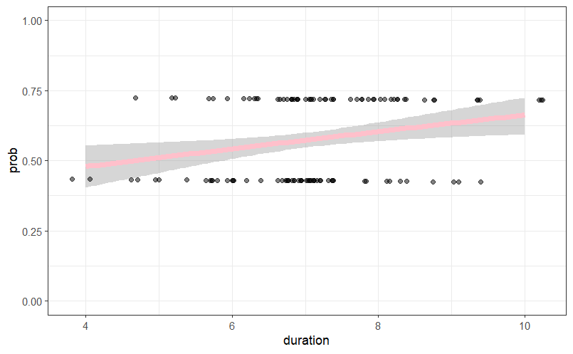

```r
ggplot(data = data, aes(x=duration, y = prob))+
  stat_smooth(method="glm"
              , se=T
              , method.args = list(gaussian(link = 'logit'))
              , colour = 'pink'
              , size = 2)+
  geom_jitter(alpha=.5, height = 0) +
  ylim(c(0,1))+
  theme_bw()
```

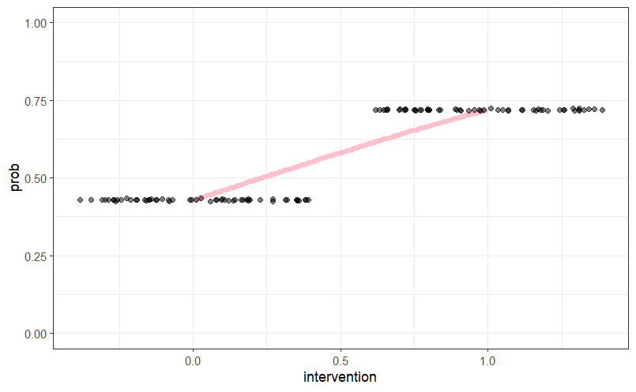

```r
ggplot(data = data, aes(x=intervention, y = prob))+
  stat_smooth(method="glm"
              , se=T
              , method.args = list(gaussian(link = 'logit'))
              , colour = 'pink'
              , size = 2)+
  geom_jitter(alpha=.5, height = 0) +
  ylim(c(0,1))+
  theme_bw()
```

```r
effectsize(m3)
```

```
# Standardization method: refit

Parameter    | Coefficient (std.) |        95% CI
-------------------------------------------------
(Intercept)  |               0.33 | [-0.06, 0.73]
duration     |          -9.26e-03 | [-0.42, 0.40]
intervention |               0.62 | [ 0.22, 1.04]

(Response is unstandardized)
```

We can also make a classification table - how many times our model makes correct classifications on the dependet variabel.

```r
#What percentage is correct?
correct_prediction.1/length(data$cured)
```

```
[1] 0.6460177
```

This is not a very good model. This model only makes correct classification 65% of the time. This is not much better than chance. This marks the end for logistic regression for now. Hopefully there is a good example of logistic regression in the wild in the chapter on real data(which don´t exist as of now). This example is quite boring in the sense that not much model building is available - we dont have a lot of variables.